# Remote Sensing, Satellite Imagery, and Google Earth Engine

4/17/2022

## Introduction and Roadmap

- Overview of basic remote sensing concepts
- Working with satellite imagery products in R
- Google Earth Engine and geospatial “big data”

## Remote Sensing: Overview

- Remote sensing techniques allow us to learn about what activities and processes taking place on the earth’s surface by extracting information about the radiation given off by objects on the earth’s surface
- A pixel in a satellite image contains information about the reflectance (at different parts of the electromagnetic spectrum) of surfaces or objects in the geographic area covered by that pixel; imagery datasets are therefore a type of raster.
- “Remote sensing” refers to the process of collecting, extracting, visualizing, and analyzing this pixel-level reflectance data
- Remote sensing techniques are used to create many of the off-the-shelf raster datasets that are widely used in applied work. For example, the population count rasters we worked with last class (clipped to NYC) are created by using remotely sensed data (that provides information on things such as land cover and night lights) that are fed into complex models that can make estimates about grid-cell population counts using these data (see [Stevens, Gaughan, Linard, and Tatem, 2015](https://journals.plos.org/plosone/article?id=10.1371/journal.pone.0107042)).

## Remote Sensing: Collecting Data

1. Sunlight strikes the earth’s surface
2. Some of it is absorbed, and some reflected back into space, where it is recorded by a sensor on a satellite (but could also be a drone, weather balloon etc.)

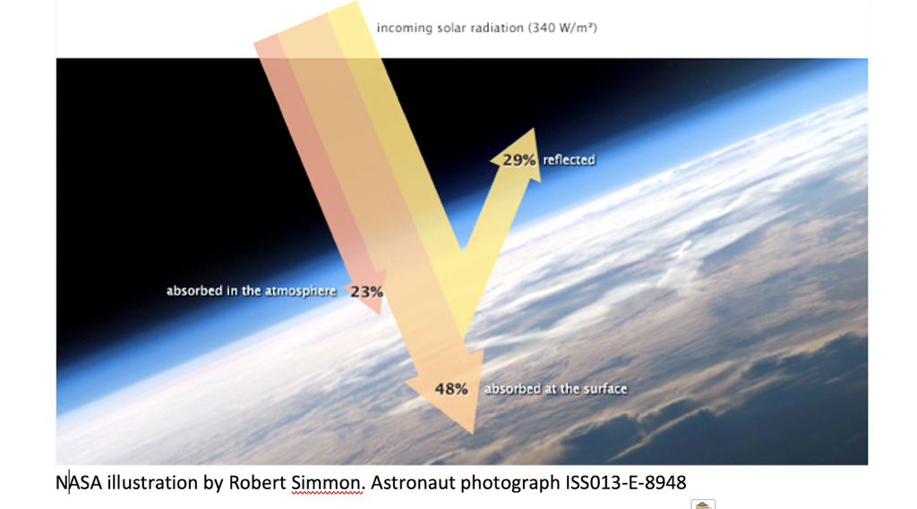

## Remote Sensing: Collecting Data, continued

- Due to their different chemical compositions, different objects or surfaces reflect sunlight in different amounts at different parts of the electromagnetic spectrum.
- In other words, various objects have different “spectral signatures”, and these different spectral signatures are recorded by the sensor positioned on the satellite. We can use these differing spectral signatures to make inferences about what sort of object is within a given pixel in an image.

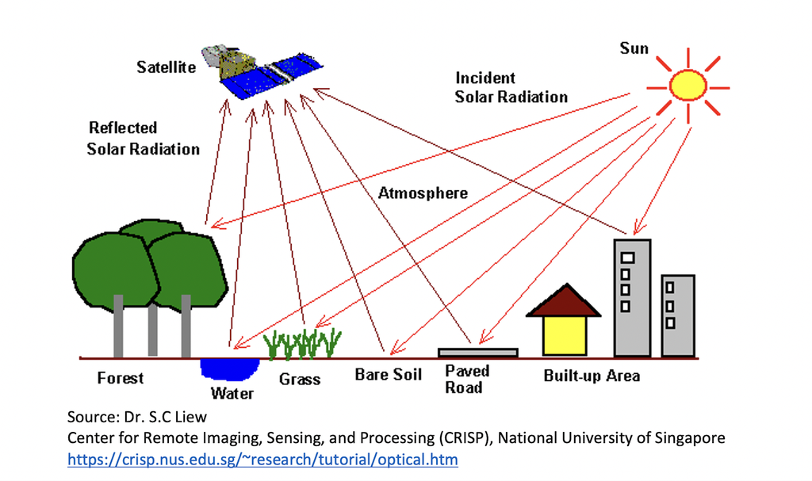

## Remote Sensing: Visualizing spectral signatures

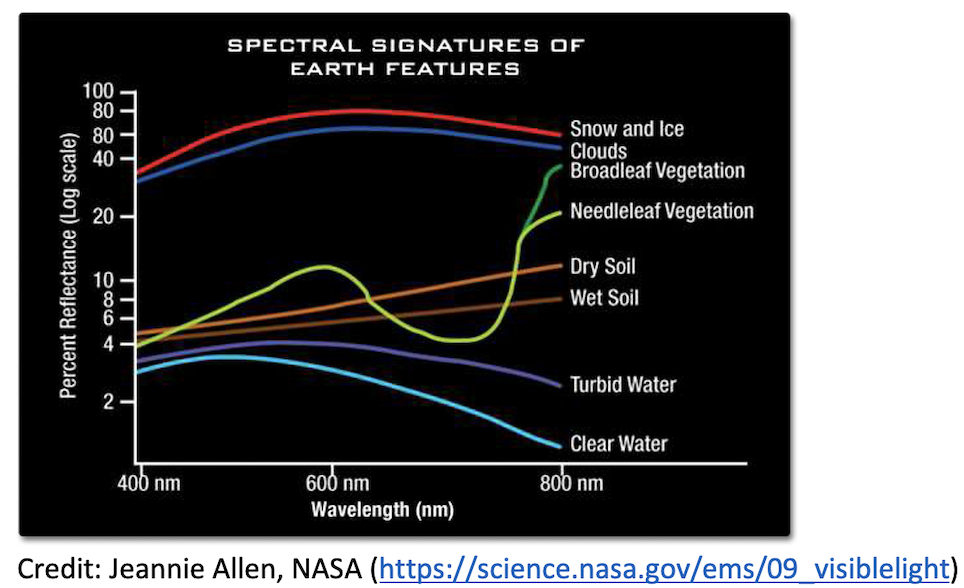

- This diagram is a visual representation of the differing spectral signatures of common objects found on the surface of the earth.
  - For example, at a wavelength of 800nm (within the near-infrared region of the electromagnetic spectrum), snow and ice have high reflectance signatures, while clear water has a very low reflectance signature. We can use these differing spectral signatures to make inferences about what sort of object is within a given pixel in a satellite image.

## Using spectral signatures to classify images: applied examples

- We can use these differing spectral signatures to make inferences about what sort of object is within a given pixel in a satellite image. In other words, we can exploit the the fact that different objects have different reflectance signatures at different parts of the electromagnetic spectrum to identify the sorts of activities or processes that are ocurring in the area delimited by a given pixel.

## Remote Sensing: Social Science Applications

As you might imagine, remote sensing is an essential tool for earth scientists and other natural scientists interested in biophysical processes.

## GEE uses

- Data archive;
- Dealing with very large datasets, or want to implement complex algorithms?

- We can use these differing spectral signatures to make inferences about what sort of object is within a given pixel in a satellite image. In other words, we can exploit the the fact that different objects have different reflectance signatures at different parts of the electromagnetic spectrum to identify the sorts of activities or processes that are ocurring in the area delimited by a given pixel.

https://gisgeography.com/spectral-signature/